# Pandas-Bootcamp-Part1

### PANDAS - Numpy and Series

### Numpy

Numpy is Numerical Python

It is a Scientific computing Library

The Fundamental Data Structure is the n-dimensional Array

An n-dimensional Array is a collection of elements.

```python
import numpy as np
import pandas as pd
```

```python
my_array = np.array([10 , 20 , 20 , 30 , 40 , 50])
```

```python
#Applying map function on an Array of numbers or a List of Numbers
#Multiply all the numbers by 10

arr = []

for i in my_array:
    arr.append(i * 10)
```

```python
arr
```

```
[100, 200, 200, 300, 400, 500]
```

#### Alternatively we can use the "map" function for the same thing

map() is a Python Funciton that works as an Iterator to return a result after applying a function to every item of an iterable (tuple, lists, etc).

It is used when you want to apply a single transformation to all the iterable elements.

The Iterable and and Function are passed as arguments to the map in Python

```python
#Creating a map object

map(lambda i : i * 10 , my_array)
```

```
<map at 0x276f4b7a070>
```

```python
#Getting the output in a List

list(map(lambda i : i * 10 , my_array))
```

```
[100, 200, 200, 300, 400, 500]
```

```python
#Getting the output in a Tuple

tuple(map(lambda i : i * 10 , my_array))
```

```
(100, 200, 200, 300, 400, 500)
```

```python
#Getting the Output in a Set

set(map(lambda i : i * 10 , my_array))  #A Set will not have any duplicate values, hence you see "200" just once
```

```
{100, 200, 300, 400, 500}
```

#### Most Pythonic way to do this :

```python
#A List comprehension

[ i * 10 for i in my_array]
```

```
[100, 200, 200, 300, 400, 500]
```

```python
#In Python we saw many ways to do this
#But in Numpy Array , its as simple as saying:

my_array * 10
```

```
array([100, 200, 200, 300, 400, 500])
```

Numpy offers a wide range of functions that are otherwise unavailable in python

Numpy Arrays are much more efficient then Python Lists

trade off : Numpy Arrays contain only one Data Type

```python
test_array = np.array([1 , 0.2  , 3])
```

```python
test_array.dtype #All other int has also been converted to Float
```

```
dtype('float64')
```

```python
test_array  = np.array([1 , 'dog'  , 3])
```

```python
#This is known as Implicit Upcasting
```

```python
test_array  #All int has been converted to String
```

```
array(['1', 'dog', '3'], dtype='<U11')
```

Hence , Numpy makes sure all elements are of same data type

### Pandas Series

#### Series are :

- One- dimensional
- Labelled Arrays
- Any Data Type

#### or said differently

- A sequence of values with associated Labels

```python
students = ['Andrew' , 'Brie' , 'Kanika']
```

```python
type(students)
```

```
list
```

In order to generate a Pandas Series out of this Python List , we simply use this Series constructor which is available in the Pandas Module and we pass the List as an Argument.

```python
pd.Series(students)
```

```
0    Andrew
1      Brie
2    Kanika
dtype: object
```

```python
ages = [27 , 49  , 37]
```

```python
pd.Series(ages)
```

```
0    27
1    49
2    37
dtype: int64
```

```python
heights = [167.4 , 173.2 , 190.0]
```

```python
pd.Series(heights)
```

```
0    167.4
1    173.2
2    190.0
dtype: float64
```

Pandas Series supports mixed Data types

```python
mixed = [True , 'Say' , {'my_mood' : 100}]
```

```python
pd.Series(mixed)
```

```
0                True
1                 Say
2    {'my_mood': 100}
dtype: object
```

### Parameters VS Arguments

Above we were passing Pandas List as Argument to the "data" parameter

pd.Series(mixed)

or

pd.Series(data = mixed)

Arguments are the actual values that we associate with the Parameters

```python
def greeting(something):
    print(something)
```

```python
greeting("Good Morning to you")
```

```
Good Morning to you
```

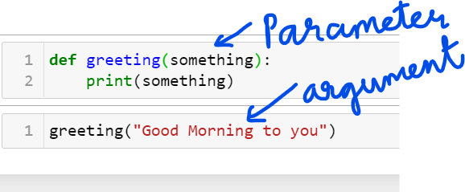

https://www.udemy.com/course/the-ultimate-pandas-bootcamp-advanced-python-data-analysis/learn/lecture/18165304#overview

### Whats in the Data

```python
import numpy as np
import pandas as pd
```

```python
books_list = ['Fooled by Randomness', 'Spiens' , 'Lenin on the Train']
```

```python
#Creating a  Pandas Series out of books_list
pd.Series(books_list)
```

```
0    Fooled by Randomness
1                  Spiens
2      Lenin on the Train
dtype: object
```

```python
#Assigning to a variable
list_s = pd.Series(books_list)
```

Above we see the Data on the right and the associated Labels on the left

```python
#Lets create a Pandas Series from Dictionary

books_dict = {0:'Fooled by Randomness', 1:'Spiens' , 2:'Lenin on the Train'}
```

```python
pd.Series(books_dict)
```

```
0    Fooled by Randomness
1                  Spiens
2      Lenin on the Train
dtype: object
```

```python
#Assigning to a variable
dict_s = pd.Series(books_dict)
```

```python
#Comparing List and Dictionary : This will do a comparison of contents in each series
#equals is a method which can be applied on a Pandas Series

list_s.equals(dict_s)
```

```
True
```

```python
list_s == dict_s
```

```
0    True
1    True
2    True
dtype: bool
```

```python
#We can also create Pandas Series using Scalars (just one number)

pd.Series(23)
```

```
0    23
dtype: int64
```

```python
pd.Series('Andy')
```

```
0    Andy
dtype: object
```

```python
ages = ['29' , '47' , 34]
```

```python
pd.Series(ages)
```

```
0    29
1    47
2    34
dtype: object
```

```python
#you can also specify the dtype
pd.Series(ages , dtype = 'float')
```

```
0    29.0
1    47.0
2    34.0
dtype: float64
```

### INDEX and RANGEINDEX

In the above examples you noticed that Pandas automatically generated the Index for us when we created the Series.

Pandas Index starts at 0 and ends at an Integer that is one less than the length of the Series.

```python
#example
age = pd.Series(ages , dtype = 'float')
```

```python
len(age)
```

```
3
```

```python
#The length of the series is 3 but the Index is ending at len(age) - 1 , that is "2"

age
```

```
0    29.0
1    47.0
2    34.0
dtype: float64
```

```python
#Creating a Brand New Series that contains our Custom labels

books_list = ['Harry Potter' , 'Panda' , 'Sci-Fi']
```

```python
pd.Series(data = books_list , index = ['FICTION' , 'COMEDY' , 'ADVENTURE'])
```

```
FICTION      Harry Potter
COMEDY              Panda
ADVENTURE          Sci-Fi
dtype: object
```

#### OR

```python
pd.Series(books_list , ['FICTION' , 'COMEDY' , 'ADVENTURE'])
```

```
FICTION      Harry Potter
COMEDY              Panda
ADVENTURE          Sci-Fi
dtype: object
```

```python
pd.__version__
```

```
'1.0.5'
```

https://www.udemy.com/course/the-ultimate-pandas-bootcamp-advanced-python-data-analysis/learn/lecture/18167220#content

So the Index that Pandas creates is a Built-in Pandas Object that is called a "Range Index"

```python
list_s
```

```
0    Fooled by Randomness
1                  Spiens
2      Lenin on the Train
dtype: object
```

```python
#Check the Index

list_s.index
```

```
RangeIndex(start=0, stop=3, step=1)
```

```python
type(list_s.index)
```

```
pandas.core.indexes.range.RangeIndex
```

#### Lets create our own Range Index

```python
#I'm accessing the Range Index Constructor on the Pandas module
```

```python
#This code returns the Range Index Object created by it

pd.RangeIndex(start =4 , stop = 7, step =1)
```

```
RangeIndex(start=4, stop=7, step=1)
```

```python
#Example 1
list(pd.RangeIndex(start = 10 , stop = -11 , step = -1))
```

```
[10, 9, 8, 7, 6, 5, 4, 3, 2, 1, 0, -1, -2, -3, -4, -5, -6, -7, -8, -9, -10]
```

```python
#Example 2
list(pd.RangeIndex(start = 10 , stop = -1 , step = -1))
```

```
[10, 9, 8, 7, 6, 5, 4, 3, 2, 1, 0]
```

```python
list_dummy = [1, 2 ,3 ,4 ,5,6]
```

```python
list(pd.RangeIndex(start=0, stop=(len(list_dummy)) , step=1))
```

```
[0, 1, 2, 3, 4, 5]
```

### Series and Index Names

```python
list_s
```

```
0    Fooled by Randomness
1                  Spiens
2      Lenin on the Train
dtype: object
```

```python
books_series = list_s
```

A Series is just a Sequence of values with associated Labels

### Method VS Attribute

ATTRIBUTE : An Attribute is a Variable bound to the Object

METHOD : A Method is a Function bound to the object

```python
#Example of an Attribute
#We are accessing a property bound to the Object

books_series.size
```

```
3
```

```python
#Example of a Method

list_s.equals(dict_s)
```

```
True
```

```python
#Example of an Attribute
#We are accessing a property bound to the Object
list_s.dtype
```

```
dtype('O')
```

### name Attribute

```python
books_series.name
```

The above code returned nothing because it has been applied to a "None" object , which means right now the books_series has got no name

```python
books_series
```

```
0    Fooled by Randomness
1                  Spiens
2      Lenin on the Train
dtype: object
```

```python
books_series.name == None
```

```
True
```

```python
#Lets give a Name to the books_series

books_series.name = "My_Fav_Books"
```

```python
books_series
```

```
0    Fooled by Randomness
1                  Spiens
2      Lenin on the Train
Name: My_Fav_Books, dtype: object
```

```python
books_series.shape   #This has got 3 Rows
```

```
(3,)
```

Whats the use of Series Name?

When we create a DataFrame , the Name of the Series will become the "Column Name"

```python
#A Series Index can also have the Name of its own
#Checking if the Index has a Name

books_series.index.name
```

```python
#Checking if the Index has no name
books_series.index.name == None
```

```
True
```

```python
#Setting Name for the Index
books_series.index.name = "books_Index"
```

```python
books_series  #We see that the Label was added to the Index
```

```
books_Index
0    Fooled by Randomness
1                  Spiens
2      Lenin on the Train
Name: My_Fav_Books, dtype: object
```

```python
books_series.shape
```

```
(3,)
```